# Predictive Analytics in Education - Building Models in R

Jared Knowles

May 30, 2019

# Predictive Analytics in Education: Building Models

## Introduction

### Objective

After completing this guide, the user will be able to fit and test a range of statistical models for predicting education outcomes. You will also be able to make predictions on future data and communicate the model fit and trade-offs of models with stakeholders.

### Using this Guide

This guide uses synthetic data created by [the OpenSDP synthetic data engine.](https://opensdp.github.io/data/) The data reflects student-level attainment data and is organized to be similar to the level of detail available at a state education agency - with a single row representing a student-grade-year. This guide does not cover the steps needed to clean raw student data. If you are interested in how to assemble data like this or the procedure used to generate the data, the code used is included in the data subdirectory.

### Getting Started

If you’re using the `Rmd` file version of these materials, start by saving a new version of the file, so you can edit it without worrying about overwriting the original. Then work through the file in RStudio by highlighting one or a few command lines at a time, clicking the “execute” icon (or pressing control-enter), and then looking at the results in the R console. Edit or add commands as you wish. If you’re using a paper or PDF version of these materials, just read on–the R output appears below each section of commands.

This guide is built using the data from the fictional state education agency of Montucky. This data set includes simulated data for multiple cohorts of 7th graders along with their corresponding high school outcomes. Each observation (row) is a student, and includes associated information about the student’s demographics, academic performance in 7th grade, associated school and district (in grade 7), last high school attended, and high school completion. For additional details on the data elements that makeup the synthetic data, there is a codebook available in the data sub-directory.

### Setup

To prepare for this project you will need to ensure that your R installation has the necessary add-on packages and that you can read in the training data. This guide also includes some custom functions you can use to make your work easier - these are read in from the `functions.R` file in the `R` directory. For details on these functions - look there.

```r
# Install add-on packages needed
install.packages("dplyr") # this will update your installed version to align with
install.packages("pROC") # those in the tutorial
install.packages("devtools")
install.packages("caret") # for machine learning
install.packages("future") # for multicore processing on Windows/Mac/Linux
```

```r
# Load the packages you need
library(dplyr)
library(pROC)
library(devtools)
library(future)
library(klaR)

# Load the helper functions not in packages
source("../R/functions.R")

# Read in the data
# This command assumes that the data is in a folder called data, below your
# current working directory. You can check your working directory with the
# getwd() command, and you can set your working directory using the RStudio
# environment, or the setwd() command.

load("../data/montucky.rda")
sea_data <- as.data.frame(sea_data) # make sure the data is a data frame
# RESUME PREPPING DATA FROM GUIDE 1
sea_data$sid <- paste(sea_data$sid, sea_data$sch_g7_lea_id, sep = "-")
sea_data$scale_score_7_math[sea_data$scale_score_7_math < 0] <- NA
```

### Outline

Here are the steps:

1. Prepare the Data for Training
2. Fit New Models
3. Evaluate Model Fit
4. Explore the Fitted Model Objects
5. Compare Our Models to Others

In this guide, we will start from a data set that has been prepared, but if you are applying this to work in your organization, it’s a good idea to review the Introduction to Predictive Analytics in Education guide and walk through the process of reviewing and exploring data for predictive analytics.

One last point – even though the data is synthetic, we have simulated missing data for you. In the real world, you’ll need to make predictions for every student, even if you’re missing data for that student which your model needs in order to run. Just making predictions using a logistic regression won’t be enough. You’ll need to use decision rules based on good data exploration and your best judgment to predict and fill in outcomes for students where you have insufficient data.

## Prepare the Data

### Beyond Logistic Regression

[In the last guide](https://jknowles.github.io/opensdp_predictive_analytics/opensdp_predictive_analytics.html) we ended up with a logistic regression model with several predictors. Logistic regression is where you should start. It is fast to compute, easier to interpret, and usually does a great job. However, there are a number of alternative algorithms available to you and R provides a common interface to them through the [`caret` package.](https://topepo.github.io/caret/index.html) The `train` function (as in, training the models) is the workhorse of the `caret` package. It has an extensive set of user-controlled options.

Moving away from logistic regression comes with some additional complexity. While logistic regression is robust and stable to predictors on a wide variety of scales and is inexpensive to compute - other algorithms may not have all of these advantages, even when they are more accurate. So there are additional data preparation steps we should take.

1. Build the model matrix
2. Divide the data into training and test sets
3. Scale and center predictors

The order of these operations is important. We want to avoid information from our test set of data being incorporated into our training data. This is called “information leakage” and it will lead us to be overly confident in strength of our model and to ultimately select the wrong model.

### Build the Model Matrix

When we fit the logistic regression model we used R’s formula interface to specify our model and let R handle the process of turning our data into a matrix suitable for model estimation. When fitting models using caret, it is a good practice to create the model matrix on our own. We do this for three reasons - first, not all of the algorithms accessible via the `caret::train()` function work with the formula interface. Having a model matrix allows us to take full advantage of the suite of models `caret` can access (and models outside of that as well such as `keras` models). Second, the matrix approach is more memory efficient and avoids costly data transformation operations during the fitting of models - a particularly important concern when dealing with datasets with many rows and/or predictors. Third, it provides us a good opportunity to check our data again and identify potential model building issues such as extremely sparse factor categories, duplicated variables, or perfectly collinear predictors.

One workflow for doing this is the annotated R code below, which uses the data preparation functions built into the `caret` package to help build model matrices that can be applied to training and test data together.[^1] The basic outline is that we manually build a matrix of indicator variables for our categorical variables and we identify and store a vector of names of our continuous variables. This will allow us to process these variables separately throughout the model building process.

```r
library(caret) # machine learning workhorse in R

# Expand categorical variables
# First declare any variable we want to be treated as a category as a factor
sea_data$frpl_7 <- factor(sea_data$frpl_7)
sea_data$male <- factor(sea_data$male)
# Use the dummyVars function to build an expansion function to expand our data
expand_factors <- caret::dummyVars(~ race_ethnicity + frpl_7 + male,
                            data = sea_data)
# Create a matrix of indicator variables by using the predict method for the
# expand_factors object we just created. There are other ways you can do this, but
# the advantage is we can use the `expand_factors` object on future/different
# datasets to preserve factor levels that may not be present in those (like our
# test set perhaps)
fact_vars <- predict(expand_factors, sea_data)
# Get the column names of our categorical dummy variables
categ_vars <- colnames(fact_vars)
# Combine the new dummy variables with our original dataset
sea_data <- cbind(sea_data, fact_vars)
# Drop the matrix of dummy variables
rm(fact_vars)
# Define the numeric/continuous predictors we want to use
continuous_x_vars <- c('scale_score_7_math', 'scale_score_7_read',
                          'pct_days_absent_7', 'sch_g7_frpl_per')
```

### Training / Test Data

Now that we have defined our model matrix and prepared our data for a variety of algorithms, we need to define our training and test data split. There are a number of ways you can split your data to estimate your out-of-sample model accuracy, but here we will opt for a temporal split where we fit the model to the earliest years of data in our model and hold out the most recent year in our data for “testing” the model fit.[^2]

```r
train_idx <- row.names( # get the row.names to define our index
  na.omit(sea_data[sea_data$year %in% c(2003, 2004, 2005),
                   # reduce the data to rows of specific years and not missing data
                   c(continuous_x_vars, categ_vars)])
  # only select the predictors we are interested in
)
test_idx <- !row.names(sea_data[sea_data$year > 2005,]) %in% train_idx
```

#### Missingness

The caret package does not automatically handle missing data, so we have to do some additional work when we define our training/test data split. You can choose additional ways to address missing data (imputation, substituting mean values, etc.) - here we opt for the simple but aggressive strategy of excluding any row with missing values for any predictor from being in the training data.[^3]

#### Outliers

This is not directly covered here, but you will also want to ensure outliers are dropped from your training data at this stage (if not earlier).

### Scale and Center Predictors

The reason we scale and center our continuous predictors last is that scaling and centering the data is - in a way - fitting a model to the data. We do not want information from the test set to carry over to the training set - which it would if we scaled and centered the entire dataset together. So we get the scaling and centering parameters on the training set, and we then apply those parameters to both the training and the test data.

When switching away from logistic regression, it is important to transform predictors to be centered at 0 with a standard deviation of 1. This helps put binary and continuous indicators on a similar scale and helps avoid problems associated with rounding, large numbers, and the optimization algorithms used to evaluate model fit. Here is an example of how you can do this in R:

```r
# Fit the data transformation model to the continuous variables in our data
pre_proc <- caret::preProcess(sea_data[train_idx, continuous_x_vars],
                       method = c("scale", "center"))

# We now have a pre-processing object which will scale and center our variables
# for us. It will ignore any variables that are not defined within it, so we
# can pass all of our continuous and dummy variables to it to produce our
# final data frame of predictors.
preds <- predict(pre_proc,
                 sea_data[train_idx, # keep only the training rows
                          c(continuous_x_vars, categ_vars)]
                 ) # keep only the columns of dummy and continuous variables
```

## Train Models

Now we have prepared our data we are ready to begin the process of setting up our model training and then fitting our models. A key difference between many of the algorithms available through `caret` and more traditional models like logistic regression, is that many algorithms have parameters that are set by the user - not learned from the data (these are sometimes callled hyperparameters). To evaluate these models then and find a good fit to the data, we need to fit them at several different values of these parameters and identify the values that best predict our outcome. This process is examined in detail below:

### Prepare the Model Fitting Parameters

Once we have defined our predictor variables, we need to tell `train()` how we want to test our models. Our goal is to experiment with the “tuning” or “hyper” parameters for our algorithms and find the values that predict the outcome best. To do this, we must tell `train()` which values to try, and how to evaluate their performance.

1. Set up R to use the computing resources on our machine

```r
# Take advantage of all the processing power on your machine
library(doFuture)
plan(multiprocess(workers = 4)) # define the number of cpus to use
registerDoFuture() # register them with R
```

2. Prep our outcome variable

Caret really really really likes if you do binary classification that you code the variables as factors with alphabetical labels. In this case, we recode 0/1 to be nongrad, grad. We also split the outcome variable off from the data and store it separately now as its own vector.

```r
yvar <- sea_data[train_idx, "ontime_grad"] # save only training observations
yvar <- ifelse(yvar == 1, "grad", "nongrad")
yvar <- factor(yvar)
```

3. Set up our model test parameters

Caret has a number of complex options, you can read about under `?trainControl`. Here we set some sensible defaults

```r
set.seed(2532) # set seed so models are comparable

example_control <- trainControl(
  method = "cv", # we cross-validate our model to avoid overfitting
  classProbs = TRUE,  # we want to be able to predict probabilities, not just binary outcomes
  returnData = TRUE, # we want to store the model data to allow for postestimation
  summaryFunction = twoClassSummary, # we use the twoClassSummary for two-class accuracy measures
  trim = TRUE, # we want to reduce the size of the final model object to save RAM
  savePredictions = "final", # we want to store the predictions from the final model
  returnResamp = "final", # we want to store the resampling code to directly compare other methods
  allowParallel = TRUE # we want to use all the processors on our computer if possible
  )

# On a standard desktop/laptop it can be necessary to decrease the sample size
# to train in a reasonable amount of time. For the prototype and getting feedback
# it's a good idea to stick with a reasonable sample size of under 20,000 rows.
# Let's do that here:

train_idx_small <- sample(1:nrow(preds), 2e4)
```

### Train the Models

And then we are ready to fit our model to the data:

For the most part this is similar to fitting a model via `lm()` - we assign the model fit an object name and call `train()`. The distribution of parameters between `train()` and those we specified above in the `trControl()` object. The key parameters to `train()` are given below with comments explaining how each of them works.

```r
# This will take quite some time:
rpart_model <- train(
  y = yvar[train_idx_small], # specify the outcome, here subset
  # to the smaller number of observations
  x = preds[train_idx_small, ], # specify the matrix of predictors, again subset
  method = "rpart",  # choose the algorithm - here a regression tree
  tuneLength = 12, # choose how many values of tuning parameters to test
  trControl = example_control, # set up the conditions for the test (defined above)
   metric = "ROC" # select the metric to choose the best model based on
  )
```

The `train()` function trains our model by splitting the data using a resampling strategy - in this case crossvalidation - and applying the algorithm of our choice to the resampled data. A key difference for algorithms fit through `train()` and a traditional logistic regression model is the presence of tuning parameters - model parameters not tied to data. These are options that we have to specify as the user. The `train()` function searches possible values of these parameters and learns the value that performs best on our data - this process is often called tuning. For a deeper explanation of how this works and what [is going on in `train()` see this writeup.](http://zevross.com/blog/2017/09/19/predictive-modeling-and-machine-learning-in-r-with-the-caret-package/#easy-data-splitting)

The `rpart_model` object produced by `train()` includes not only the final tuned model, but also the results of the training experiment including the model performance for each value of the tuning parameter. Much of the art of predictive analytics is in defining the tuning parameter search space, choosing the correct model performance metric, and specifying the correct resampling strategy to correctly estimate model performance on future data. The result of this process is a meta-model that is estimating the likely performance of the model at different tuning parameter values in predicting future data.

To fit a second model it’s as easy as changing the `method` argument to caret and specifying a new method. In this case we will use the same training process, but we will tune fewer values of the tuning parameters for this new algorithm.[^4]

```r
# Repeat above but just change the `method` argument to GBM for gradient boosted machines
treebag_model <- train(y = yvar[train_idx_small],
             x = preds[train_idx_small,],
             method = "treebag", tuneLength = 4,
             trControl = example_control,
             metric = "ROC")
```

This object uses the `treebag` method. Note that `caret` tries to provide a unified interface to over 200 algorithm types available in R. Not all of these algorithms are suitable for modeling all types of data and many of these methods will require the installation of additional R packages. When exploring your algorithm options it can be helpful to consult a textbook and to review available methods by their “family” to identify which algorithmic families may be most efficient for your problem at hand.

#### Look at Our Models

When we print out the model objects we do not get a list of coefficients and table of statistical significance as we would with a linear model - instead we get the results of our model training experiment: a table of model performance statistics for every value of the tuning parameter. Notice that the `rpart_model` object has multiple rows of results, but the `treebag_model`, which has no tuning parameters to be learned from the data, has just a single row.

```r
print(rpart_model)
```

```
CART

20000 samples
   17 predictor
    2 classes: 'grad', 'nongrad'

No pre-processing
Resampling: Cross-Validated (10 fold)
Summary of sample sizes: 18000, 17999, 18001, 18000, 18000, 17999, ...
Resampling results across tuning parameters:

  cp            ROC        Sens       Spec
  0.0009563043  0.6938150  0.8816933  0.3932617
  0.0009808249  0.6938294  0.8810115  0.3937035
  0.0011769898  0.6946771  0.8925235  0.3751713
  0.0012505517  0.6951995  0.8942658  0.3714918
  0.0015447992  0.6958360  0.8968410  0.3664894
  0.0016674023  0.6957982  0.8955531  0.3697282
  0.0027953509  0.6929403  0.9035054  0.3513244
  0.0028689128  0.6925184  0.9042624  0.3477898
  0.0036045314  0.6903971  0.9124425  0.3295545
  0.0091216713  0.6877186  0.8970734  0.3491215
  0.0426658820  0.6793263  0.8366946  0.4270950
  0.0508312491  0.6206484  0.8699651  0.3110788

ROC was used to select the optimal model using the largest value.
The final value used for the model was cp = 0.001544799.
```

```r
print(treebag_model)
```

```
Bagged CART

20000 samples
   17 predictor
    2 classes: 'grad', 'nongrad'

No pre-processing
Resampling: Cross-Validated (10 fold)
Summary of sample sizes: 18001, 18000, 18000, 18001, 18000, 17999, ...
Resampling results:

  ROC        Sens       Spec
  0.6945625  0.8242807  0.429012
```

The best value of the tuning parameter is chosen by selecting the value that optimizes the performance metric we specified to `trainControl()` - in this case, the `ROC` that is maximized. This value is only measured on the holdout set in our cross-validation startegy.

## Model Comparison

Our next step is to compare our two models. One quick way to do this is to compare the prediction performance of each of the models across all of the folded holdout sets. This results in 10 estimates of out of sample performance. We can plot these estimates to see how the distribution of out of sample performance metrics compares between two models. The `resamples()` function in caret makes this easy:

```r
# Construct a list of model performance comparing the two models directly
resamps <- caret::resamples(list(RPART = rpart_model,
              TREEBAG = treebag_model))
# Summarize it
summary(resamps)
```

```
Call:
summary.resamples(object = resamps)

Models: RPART, TREEBAG
Number of resamples: 10

ROC
             Min.   1st Qu.    Median      Mean   3rd Qu.      Max. NA's
RPART   0.6860428 0.6895883 0.6951502 0.6958360 0.6982414 0.7080971    0
TREEBAG 0.6818932 0.6863913 0.6905270 0.6945625 0.6972216 0.7317117    0

Sens
             Min.   1st Qu.    Median      Mean   3rd Qu.      Max. NA's
RPART   0.8651515 0.8933712 0.8977651 0.8968410 0.9054924 0.9136364    0
TREEBAG 0.8022727 0.8153749 0.8261364 0.8242807 0.8320397 0.8433005    0

Spec
             Min. 1st Qu.    Median      Mean   3rd Qu.      Max. NA's
RPART   0.3382353 0.35625 0.3627675 0.3664894 0.3832268 0.3926471    0
TREEBAG 0.3991163 0.41250 0.4253130 0.4290120 0.4430147 0.4750000    0
```

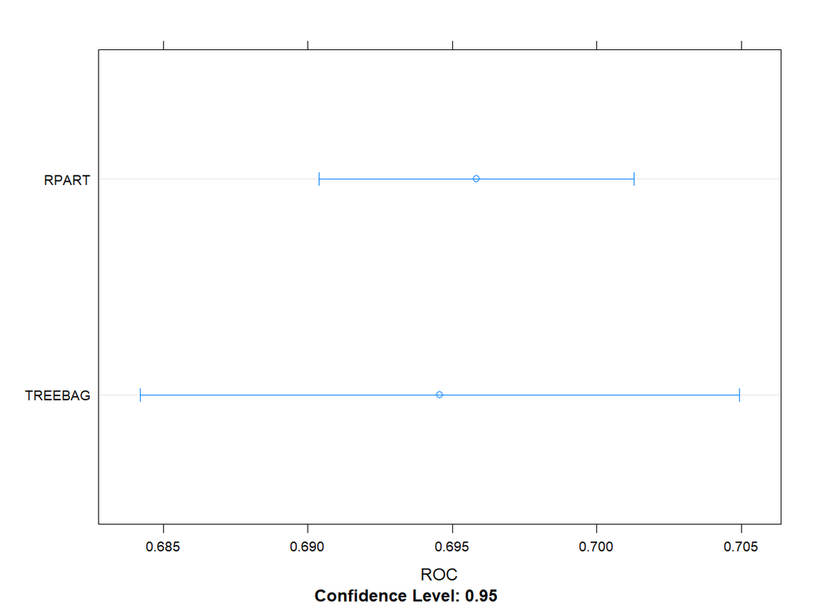

```r
# plot it
# see ?resamples for more options
dotplot(resamps, metric = "ROC")
```

This shows us that while the best performance of the `treebag_model` exceeded that of the `rpart_model` - there is quite a lot of overlap when the experiment is repeated ten times. This will often be the case and the amount of variability in out of sample performance (variance) is an important factor to take into account when selecting models. It isn’t just simply a matter of taking the model that maximizes the cross-validated ROC - we may need to factor in the variability in that outcome and the cost in terms of time and computing power necessary to get that result.

Ultimately, this plot only tells us about our results on the data we have used in training. We are estimating our accuracy on the cross-validated resamples on the training data. In our case, that means each model has it’s performance estimated 10 times on a 2,000 row subset of the data (nrows / K) that was not seen for that particular tuning parameter. What we really care about is how the model performs on future cohorts, and this is why we left some of our data out of the model building process altogether as a validation set. It’s time now to assess the performance of these two models on that future cohort.

## Predict and Out of Sample Validation

Now we need to evaluate our performance on our hold-out set of data. Remember that we split our data up by time so our model has been trained on cohorts from the earlier years in our data. The true test of our model comes in seeing how well it predicts future cohorts of students - cohorts the model has never seen. This is where we see how robust the model is to changes in the measures used and secular patterns in student attainment.

This is a little more involved than running the predict command - we need to transform our test data using the exact same process and parameters we used to transform the training data. Luckily we stored the `pre_proc` object which we can now apply to the test dataset. Then we recode the outcome variable for the test data, which we will use to compare our model predictions to.

We can use a number of different approaches in R to evaluate model performance, but since we are already using the `caret` package we can use its built in `confusionMatrix()` function to compare the observed graduation status of students with the predictions from our models above on the new data object `test_data`.

```r
# We use the pre-processing we defined on the training data, but this time
# we create test_data with these values:

test_data <- predict(pre_proc,
                     sea_data[test_idx, # specify the rows in the test set
                        c(continuous_x_vars, categ_vars)]) # keep the same vars

# Create a vector of outcomes for the test set
test_y <- sea_data[test_idx, "ontime_grad"]
test_y <- ifelse(test_y == 1, "grad", "nongrad")
test_y <- factor(test_y)

confusionMatrix(reference = test_y, data = predict(rpart_model, test_data),
                positive = "nongrad", mode = "everything")
```

```
Confusion Matrix and Statistics

          Reference
Prediction  grad nongrad
   grad    72734   26841
   nongrad  8353   15860

               Accuracy : 0.7157
                 95% CI : (0.7132, 0.7182)
    No Information Rate : 0.655
    P-Value [Acc > NIR] : < 2.2e-16

                  Kappa : 0.2991

 Mcnemar's Test P-Value : < 2.2e-16

            Sensitivity : 0.3714
            Specificity : 0.8970
         Pos Pred Value : 0.6550
         Neg Pred Value : 0.7304
              Precision : 0.6550
                 Recall : 0.3714
                     F1 : 0.4740
             Prevalence : 0.3450
         Detection Rate : 0.1281
   Detection Prevalence : 0.1956
      Balanced Accuracy : 0.6342

       'Positive' Class : nongrad
```

```r
# Note that making predictions can take a long time
# consider alternative models or making fewer predictions if this is a bottleneck
confusionMatrix(reference = test_y, data = predict(treebag_model, test_data),
                positive = "nongrad",  mode = "everything")
```

```
Confusion Matrix and Statistics

          Reference
Prediction  grad nongrad
   grad    69585   20339
   nongrad 11502   22362

               Accuracy : 0.7428
                 95% CI : (0.7403, 0.7452)
    No Information Rate : 0.655
    P-Value [Acc > NIR] : < 2.2e-16

                  Kappa : 0.4015

 Mcnemar's Test P-Value : < 2.2e-16

            Sensitivity : 0.5237
            Specificity : 0.8582
         Pos Pred Value : 0.6603
         Neg Pred Value : 0.7738
              Precision : 0.6603
                 Recall : 0.5237
                     F1 : 0.5841
             Prevalence : 0.3450
         Detection Rate : 0.1806
   Detection Prevalence : 0.2736
      Balanced Accuracy : 0.6909

       'Positive' Class : nongrad
```

This allows us to compare the models on a wide range of possible performance metrics to see what tradeoffs there are between them. It looks like, despite having fewer tuning parameters, the `treebag_model` is outperforming the `rpart_model` on the validation set.

Let’s look at this graphically as well: We can also make ROC plots of our test-set, out of sample, prediction accuracy.

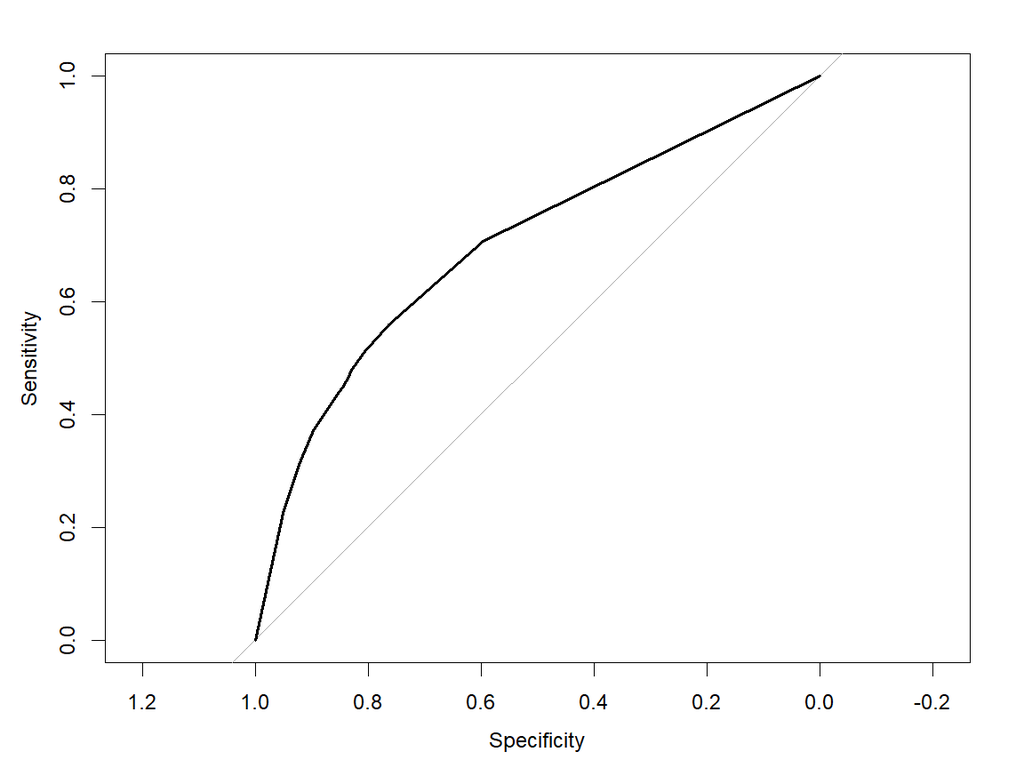

```r
# ROC plots
yhat <- predict(rpart_model, test_data, type = "prob")
yhat <- yhat$grad
roc(response = test_y, predictor = yhat <- yhat) %>% plot
```

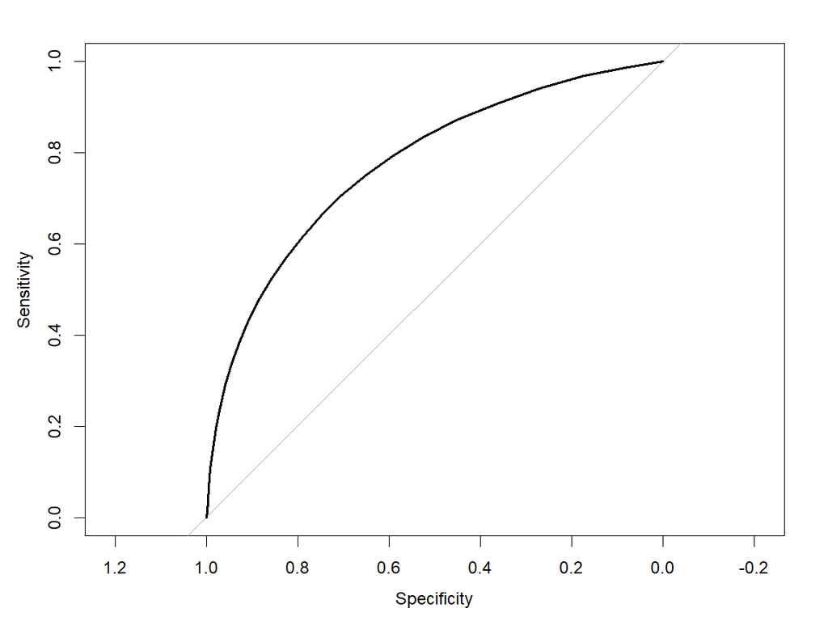

```r
# TB ROC plot
yhat <- predict(treebag_model, test_data, type = "prob")
yhat <- yhat$grad
roc(response = test_y, predictor = yhat <- yhat) %>% plot
```

## Predicting on Future Data

Now that you’ve picked your model you need to be able to put it into production and predict the future outcomes for current students. This guide includes simulated current student data (student data without an observed outcome) so you can walk through the process of applying your trained models to this new data.

This process is called model scoring. The key step here is that we have to pre-process the current data the exact same way we pre-processed the training data. In this case we can apply the `preproc` object we used above to the current data - assuming we are using the same variable names and have done the same work converting indicator data to factors.

```r
load("../data/montucky_current.rda")

current_data$frpl_7 <- factor(current_data$frpl_7)
current_data$male <- factor(current_data$male)
fact_vars <- predict(expand_factors, current_data)
# Get the column names of our categorical dummy variables
categ_vars <- colnames(fact_vars)
# Combine the new dummy variables with our original dataset
pred_data <- cbind(current_data, fact_vars)


pred_data <- predict(pre_proc,
                     pred_data[ ,
                        c(continuous_x_vars, categ_vars)]) # keep the same vars


preds_treebag <- predict(treebag_model, newdata = pred_data, type = "prob")$grad
preds_rpart <- predict(rpart_model, newdata = pred_data, type = "prob")$grad

current_data <- bind_cols(current_data,
                          data.frame(preds_treebag),
                          data.frame(preds_rpart))
str(current_data)
```

```
'data.frame':   34321 obs. of  36 variables:
 $ sid                 : chr  "0001" "0004" "0005" "0019" ...
 $ sch_g7_code         : chr  "01-01" "01-07" "01-07" "01-08" ...
 $ year                : num  2018 2018 2018 2018 2018 ...
 $ grade               : chr  "7" "7" "7" "7" ...
 $ scale_score_7_math  : num  30.9 35.4 40.8 40.3 42.8 ...
 $ scale_score_7_read  : num  32.4 40.8 33.6 46.9 25.6 ...
 $ age                 : num  12 12 12 12 12 12 12 12 12 12 ...
 $ frpl_7              : Factor w/ 4 levels "0","1","2","9": 2 2 1 1 2 3 1 1 1 1 ...
 $ ell_7               : num  0 0 0 0 0 0 0 0 0 0 ...
 $ iep_7               : num  0 0 0 0 0 1 0 1 0 0 ...
 $ gifted_7            : num  0 0 0 0 1 1 0 0 0 0 ...
 $ cohort_year         : num  2008 2008 2008 2008 2008 ...
 $ pct_days_absent_7   : num  0 0 0 0 8.89 ...
 $ male                : Factor w/ 2 levels "0","1": 2 1 1 1 NA 2 2 2 1 1 ...
```

[output cut: 22 more lines]

## Advanced Techniques

Predictive analytic techniques are constantly being refined and evolving. This section will review a few techniques that I have found helpful when doing predictive analytic work with education data.

### Regression Trees

Many of the most popular machine learning algorithms implemented on tabular data, data structured with rows and columns, are tree algorithms. Regression tree algorithms come in many different flavors (forests, boosted trees, pruned trees, etc.), but the basic strategy is to partition the data by splits in the available predictors so each branch of the tree uniquely identifies a specific combination of values of predictors that divide the outcome well between the two groups.

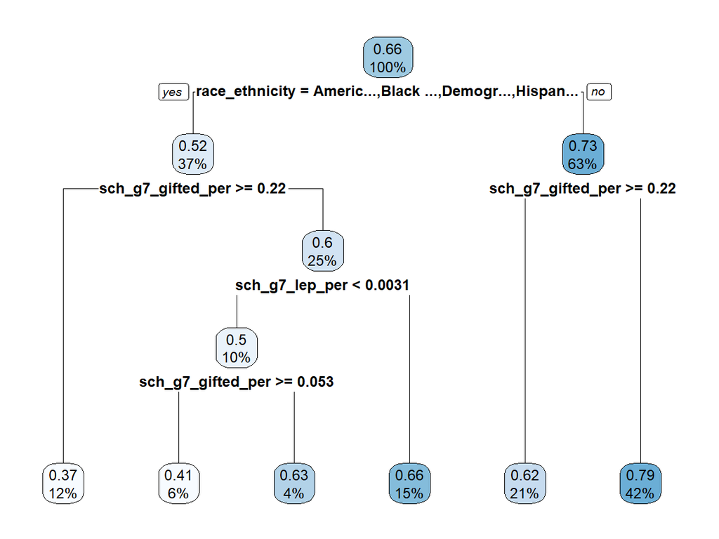

```r
########################################################################
# Build and plot a regression tree
########################################################################
library(rpart.plot)
library(rpart)

# Basic partition tree model to plot
binary.model <- rpart(ontime_grad ~ scale_score_7_math +
                       pct_days_absent_7 + ell_7 + iep_7 + frpl_7 + male +
                       race_ethnicity +
                       sch_g7_lep_per + sch_g7_gifted_per,
                     data = sea_data,
                     control = rpart.control(cp = .005))

# Pass the model object to the plot function
# You can look at ?rpart.plot to identify customizations you wish to use
rpart.plot(binary.model)
```

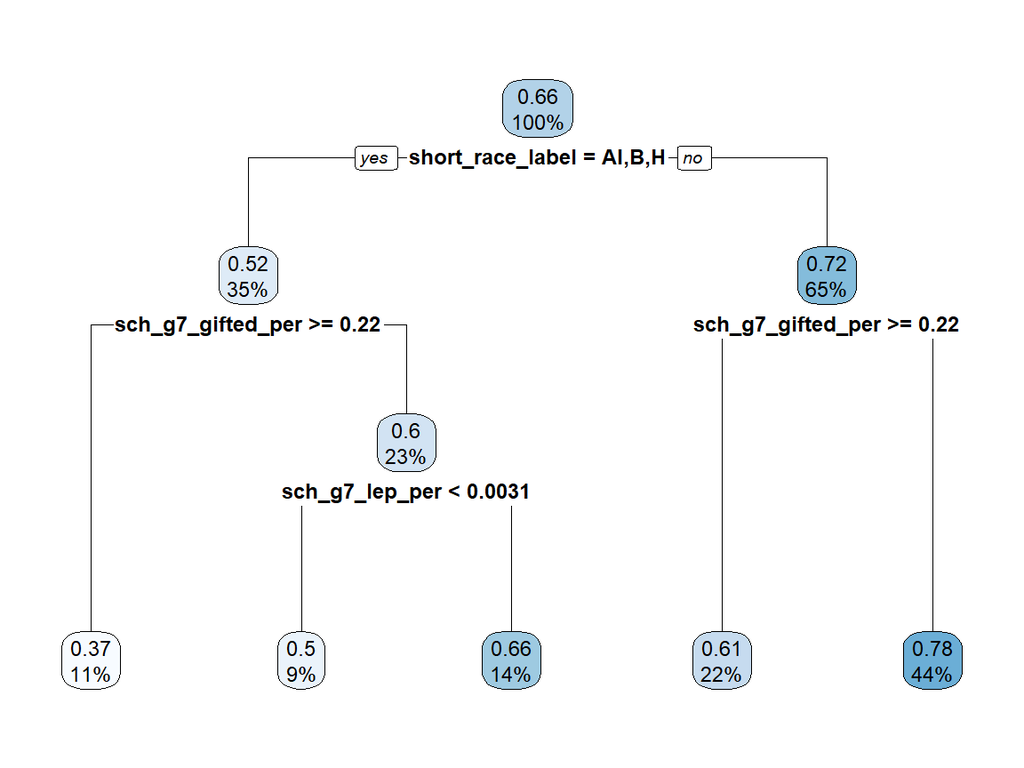

```r
# To improve the labels, you can rename the variables in the data
sea_data$short_race_label <- NA
sea_data$short_race_label[sea_data$race_ethnicity == "Hispan..."] <- "H"
sea_data$short_race_label[sea_data$race_ethnicity == "White"] <- "W"
sea_data$short_race_label[sea_data$race_ethnicity == "Asian"] <- "A"
sea_data$short_race_label[sea_data$race_ethnicity == "Americ..."] <- "AI"
sea_data$short_race_label[sea_data$race_ethnicity == "Demogg..."] <- "M"
sea_data$short_race_label[sea_data$race_ethnicity == "Native..."] <- "HA"
sea_data$short_race_label[sea_data$race_ethnicity == "Black ..."] <- "B"

# Fit a classification model, just like a logistic regression formula interface
binary.model <- rpart(ontime_grad ~ scale_score_7_math +
                        pct_days_absent_7 + ell_7 + iep_7 + frpl_7 + male +
                        short_race_label +
                        sch_g7_lep_per + sch_g7_gifted_per,
                      data = sea_data,
                      control = rpart.control(cp = .005))

# Make a plot showing the tree
rpart.plot(binary.model)
```

### Variable Importance

Another important diagnostic tool is understanding what variables/predictors are providing most of the differentiation between the two classes. In regression analysis, we can use regression coefficients. For many of the models that we can access using `caret`, there are no coefficients produced. Instead we have to use alternative methods to measure the influence that predictors have on the outcome. For many of the algorithms we can analyze using `caret` we can ask it to compute the “variable importance”, a measure of the relative influence, for the predictors in the model.

We can also plot these values in a graph and inspect it visually.

```r
########################################################################
## Variable importance from a caret/train model object
########################################################################

# Get variable importance, not available for all methods
caret::varImp(rpart_model)
```

```
rpart variable importance

                            Overall
sch_g7_frpl_per           100.00000
frpl_7.0                   56.69920
race_ethnicityWhite        42.22320
frpl_7.1                   24.24906
scale_score_7_math         23.23764
race_ethnicityHispan...    13.78622
race_ethnicityAsian         9.98040
race_ethnicityBlack ...     9.96223
scale_score_7_read          4.86640
frpl_7.2                    1.26058
male.1                      0.29758
male.0                      0.29672
race_ethnicityAmeric...     0.28157
pct_days_absent_7           0.24250
frpl_7.9                    0.06089
`race_ethnicityBlack ...`   0.00000
race_ethnicityDemogr...     0.00000
race_ethnicityNative...     0.00000
```

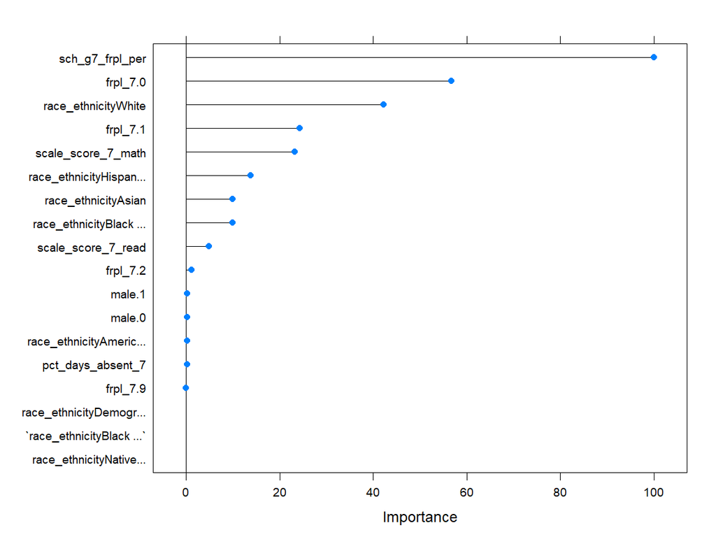

```r
# Plot variable importance
plot(caret::varImp(rpart_model))
```

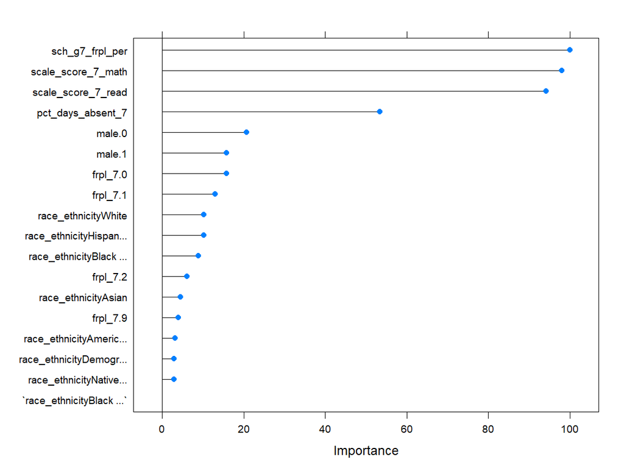

```r
plot(caret::varImp(treebag_model))
```

The difference between the importance of the predictors in each model helps us to understand the different ways each model is arriving at its predictions. This is a convenient way to get an at a glance look at what is driving the predictions of our model inside the black box.[^5]

### Probability Trade offs

Another key aspect to predicting binary outcomes is deciding, as we saw in the first guide, how strong the predicted probability of an outcome has to be before we classify a student into a particular category. When we are working with binary outcomes, it can be helpful to use the ROC plot approach to evaluate at which point in the probability distribution we are identifying enough students without raising too many false alarms.

The `yardstick` package for R provides a useful interface for quickly comparing many models on a number of performance metrics, including making tradeoff plots.

```r
########################################################################
## Probablity accuracy
## Plot the relationship between predicted probabilities and observed
## graduation rates to explore thresholds.
########################################################################
library(yardstick)
library(dplyr)

# Get the predicted classifications from the caret model above
class_vec <- predict(treebag_model, newdata = test_data)
# Get the predicted probabilities from the model above
## Note that caret insists on giving probabilities for both classes, we
## need to store only one, in this case, the first one
prob_vec <- predict(treebag_model, newdata = test_data, type = "prob")[[1]] # only need first column

# Combine the true values, the estimated class, and the class probability
# into one dataframe for plotting
estimates_tbl <- data.frame(
  truth = test_y,
  estimate = as.factor(class_vec),
  class_prob = prob_vec
)

# Using this struture we can use the `yardstick` package to nicely
# compute a variety of performanc emetrics
## Confusion matrix
estimates_tbl %>% yardstick::conf_mat(truth, estimate)
```

```
          Truth
Prediction  grad nongrad
   grad    69585   20339
   nongrad 11502   22362
```

```r
# Accuracy
estimates_tbl %>% yardstick::metrics(truth, estimate)
```

```
# A tibble: 2 x 3
  .metric  .estimator .estimate
  <chr>    <chr>          <dbl>
1 accuracy binary         0.743
2 kap      binary         0.402
```

```r
# AUC
estimates_tbl %>% yardstick::roc_auc(truth, class_prob)
```

```
# A tibble: 1 x 3
  .metric .estimator .estimate
  <chr>   <chr>          <dbl>
1 roc_auc binary         0.775
```

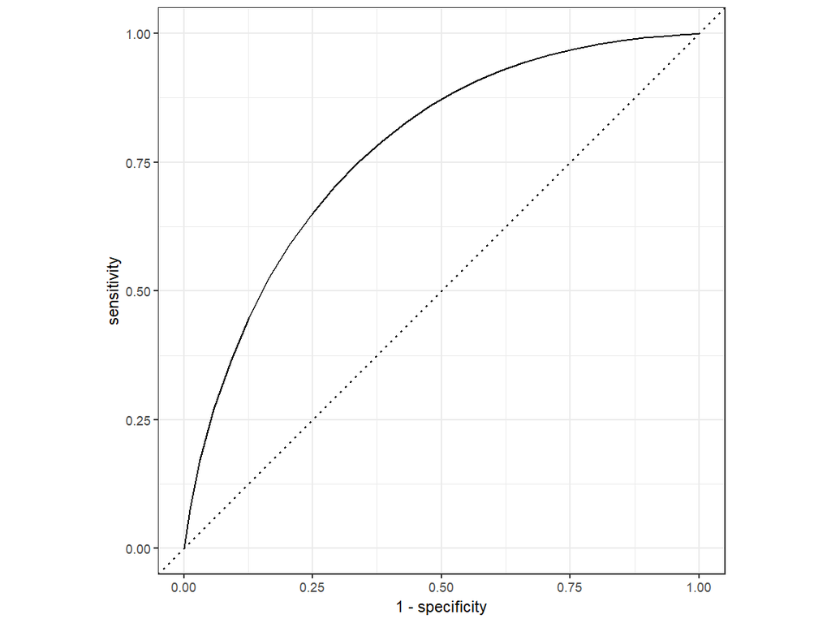

```r
# ROC graph
# Plots the ROC curve (the ROC at all possible threshold values for the
# probability cutoff)

estimates_tbl %>%
  roc_curve(truth, class_prob) %>%
  autoplot()
```

Another way to look at an individual estimated threshold is to graphically depict the confusion matrix using a mosaic plot (a visual crosstab). This code will help you do that:

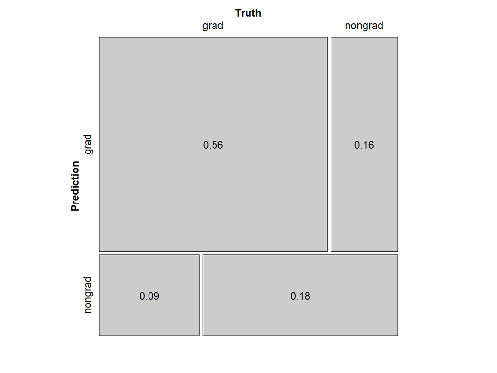

```r
# Save the confusion matrix as an R object
conf_mat <- estimates_tbl %>% yardstick::conf_mat(truth, estimate)

# Plot the confusion matrix if you like
library(vcd)
labs <- round(prop.table(conf_mat$table), 2)
# Can change the margin to change the labels
mosaic(conf_mat$table, pop = FALSE)
labeling_cells(text = labs, margin = 0)(conf_mat$table)
```

### Probability vs. Outcome Plot

Another important way to compare models is to compare how the probability prediction they generate relates to the outcome. In some cases an increase in probability will correspond very closely to an increase in observed graduation rates, but in other cases, boundaries exist in the probability space where a small change in the probability threshold can result in a large shift in the classification rates of true positives and true negatives. This is a feature that is dependent on the algorithm you use and how it was tuned, so investigating this behavior is a good post-predictive check.

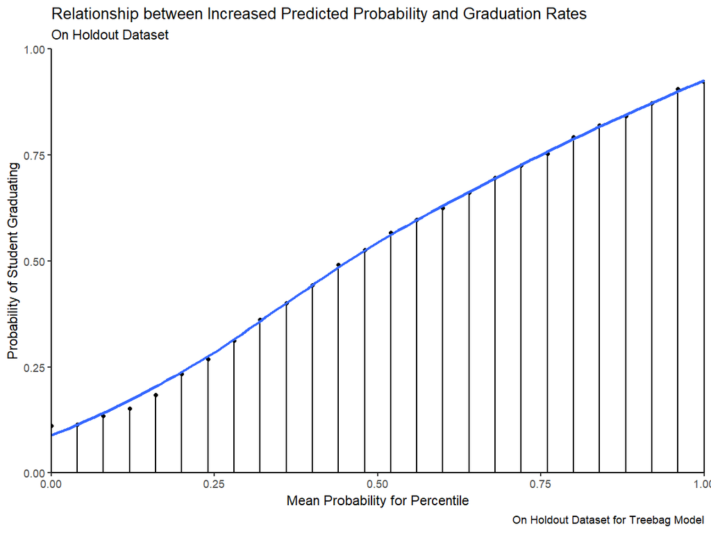

```r
################################################################################
## Probability vs. outcome plot for predicted probabilities
################################################################################

plotdf <- estimates_tbl %>%
  mutate(prob_cut = percent_rank(class_prob)) %>%
  # depending on how many unique probabilities your model produces you can try
  # mutate(prob_cut = ntile(class_prob, 50)) %>%
  group_by(prob_cut) %>%
  summarize(
    avg_prob = mean(class_prob),
    prob_grad = sum(truth == "grad") / length(truth),
    count = n())


library(ggplot2)
library(ggalt) # for fun lollipop charts

ggplot(plotdf, aes(x = avg_prob, y = prob_grad)) +
  ggalt::geom_lollipop() + theme_classic() +
  coord_cartesian(xlim = c(0, 1), ylim = c(0, 1), expand = FALSE) +
  geom_smooth(se = FALSE) +
  labs(x = "Mean Probability for Percentile",
       y = "Probability of Student Graduating",
       title = "Relationship between Increased Predicted Probability and Graduation Rates",
       subtitle = "On Holdout Dataset",
       caption = "On Holdout Dataset for Treebag Model")
```

### Make a Bowers Plot

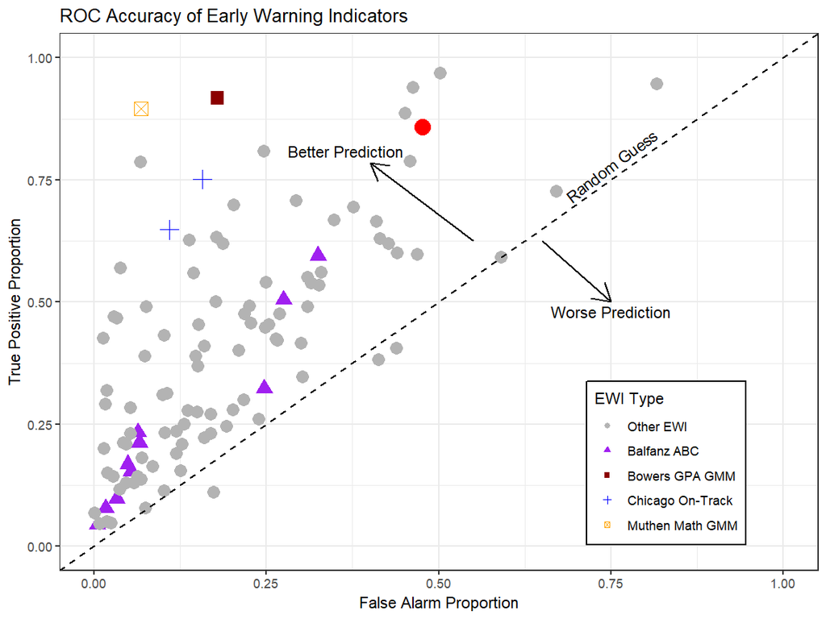

```r
# Requires internet connection
################################################################################
## Advanced: Make a Bowers plot
#################################################################################
bowers_plot() +
  # Add your annotation here:
  annotate(geom = "point",
           x = 1 - pull(estimates_tbl %>% yardstick::spec(truth, estimate)),
           y = pull(estimates_tbl %>% yardstick::sens(truth, estimate)),
           size = 5, color = "red")
```

## References and More

The `caret` package has extensive documentation which you can use to find new models, learn about algorithms, and explore many other important aspects of building predictive analytics. You can learn more here:

https://topepo.github.io/caret/

[^1]: This is one approach based on the functionality of the `caret` package which is a stable and reliable machine learning interface in R with lots of documentation and years of support. A [newer approach is in develop called `tidymodels`](https://github.com/tidymodels) - but this set of tools is, as of this writing, still developing and likely to change. It also has only a subset of the current functionality of `train`. But - keep an eye out.
[^2]: See Kuhn and Johnson, 2019. http://www.feat.engineering/data-splitting.html
[^3]: The handling of missing data in predictive analytics has no rule of thumb or default solution. It is a complex and rapidly evolving frontier for research. [See Kuhn and Johnson, 2013 for details.](http://appliedpredictivemodeling.com/)
[^4]: For a full list of methods available in the `caret` package - [see here.](https://topepo.github.io/caret/available-models.html)
[^5]: There are many other methods for interpreting machine learning models and this is one of the areas under the most active research. Most of these methods involve fitting simpler models to subsets of the predictions to explore the relationship between predictors and predictions at different points in the dataset. For a tour of machine learning model intepretation methods [visit Molnar, 2019 Interpretable Machine Learning.](https://christophm.github.io/interpretable-ml-book/agnostic.html)